# Assignment 2

## ISYE 6740 - Assignment 2 - Classification

### Q1) Linear SVM Classification

- In this question, we use the spam dataset to study linear SVM classifiers. For both training and testing data, the first 57 columns are different features of emails and the last column shows whether an email is spam (1 for spam). We will train linear SVM classifier models to predict if a given email is spam and explore how classification error changes with the parameter *C*.
- Please refer to the following package for Linear SVM classifier:\ https://scikit-learn.org/stable/modules/generated/sklearn.svm.LinearSVC
- Please standardize features in the dataset by removing the mean and scaling to unit variance. Refer to the following package for data standardization:\ https://scikit-learn.org/stable/modules/generated/sklearn.preprocessing.StandardScaler.html
- For your linear SVM model, set max_iter = $10^4$ and tol = 1e-2. Ignore the warnings of SVM.

#### a) Standardize the training set.

```python
### Import Packages
import numpy as np
import pandas as pd
import matplotlib.pyplot as plt
from tqdm import tqdm
from sklearn.svm import LinearSVC
from sklearn.preprocessing import StandardScaler
from sklearn.model_selection import train_test_split
from sklearn.metrics import accuracy_score, mean_squared_error

### Suppress Warnings
import warnings
warnings.simplefilter(action='ignore', category=Warning)
```

```python
### Import Dataset
# Load the dataset
df1_train = pd.read_csv('./SPAM_train.csv')
df1_test = pd.read_csv('./SPAM_test.csv')

# Split features and labels
X_train, y_train = df1_train.iloc[:, :-1], df1_train.iloc[:, -1]
X_test, y_test = df1_test.iloc[:, :-1], df1_test.iloc[:, -1]

# Standardize features
scaler = StandardScaler()
X_train_standardized = scaler.fit_transform(X_train)
```

#### b) Train SVM classifiers for a range of *C* values $\{10^{-5}, 10^{-4}, 10^{-3}, \ldots, 10^{1}, 10^{2}\}$ using the standardized training set.

```python
C_values = [1e-5, 1e-4, 1e-3, 1e-2, 1e-1, 1, 1e1, 1e2] # Regularization parameter (inversely proportional to C)
SVM_trained = []

for C in C_values:
    # Create a LinearSVC model with specified C, max_iter, and tol
    model = LinearSVC(C=C, max_iter=int(1e4), tol=1e-2)

    # Train the model
    model.fit(X_train_standardized, y_train)

    # Save the model
    SVM_trained.append(model)

SVM_trained
```

```
[LinearSVC(C=1e-05, max_iter=10000, tol=0.01),
 LinearSVC(C=0.0001, max_iter=10000, tol=0.01),
 LinearSVC(C=0.001, max_iter=10000, tol=0.01),
 LinearSVC(C=0.01, max_iter=10000, tol=0.01),
 LinearSVC(C=0.1, max_iter=10000, tol=0.01),
 LinearSVC(C=1, max_iter=10000, tol=0.01),
 LinearSVC(C=10.0, max_iter=10000, tol=0.01),
 LinearSVC(C=100.0, max_iter=10000, tol=0.01)]
```

#### c) Standardize the testing set using the statistics of the training set obtained in a).

```python
# Standardize features
X_test_standardized = scaler.transform(X_test)
```

#### d) Plot misclassification errors on the standardized testing set with respect to different $C$ values.

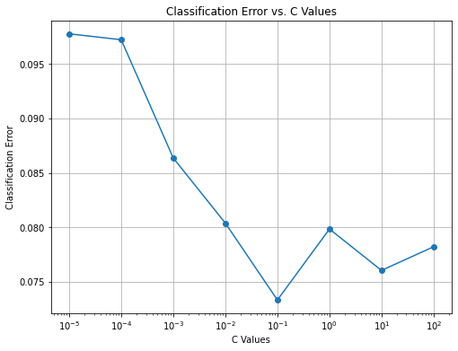

```python
# Initialize lists to store error rates for each C value
classification_errors = []
test = []
for model in SVM_trained:
    # Make predictions on the standardized testing set
    y_pred = model.predict(X_test_standardized)

    # Calculate the classification error rate
    # error_rate = 1 - model.score(X_test_standardized, y_test)

    # error_rate = np.mean(y_test != y_pred)
    error_rate = 1 - accuracy_score(y_test, y_pred)
    classification_errors.append(error_rate)

# Create a plot to visualize classification errors
plt.figure(figsize=(8, 6))
plt.plot(C_values, classification_errors, marker='o')
plt.xscale('log')  # Set x-axis to a logarithmic scale for C values
plt.xlabel('C Values')
plt.ylabel('Classification Error')
plt.title('Classification Error vs. C Values')
plt.grid(True)
plt.show()
```

#### e) Report the optimal parameter $C^*$ and its misclassifcation error.

```python
# Find the index of the minimum value in error_rates
min_index = classification_errors.index(min(classification_errors))
best_C = C_values[min_index]

print("Optimal parameter C*:", C_values[min_index])
print("Classification error C*:", min(classification_errors))
```

```
Optimal parameter C*: 0.1
Classification error C*: 0.07332971211298212
```

#### f) With the optimal parameter $C^*$ obtained in e), which training data points are support vectors? Can you visualize your results using a histogram?

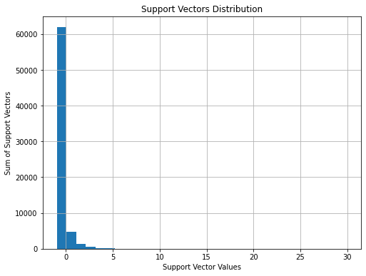

```python
# Create a LinearSVC model with the optimal C*
optimal_model = LinearSVC(C=best_C, max_iter=int(1e4), tol=1e-2)

# Train the model on the standardized training set
optimal_model.fit(X_train_standardized, y_train)

# obtain the support vectors through the decision function
decision_function = optimal_model.decision_function(X_train_standardized)
# we can also calculate the decision function manually
# decision_function = np.dot(X, clf.coef_[0]) + clf.intercept_[0]
# The support vectors are the samples that lie within the margin
# boundaries, whose size is conventionally constrained to 1
support_vector_indices = np.where(np.abs(decision_function) <= 1 + 1e-15)[0]
support_vectors = X_train_standardized[support_vector_indices]

# Create a histogram with the sums in each interval
plt.figure(figsize=(8, 6))
plt.hist(support_vectors.flatten(), bins=30)
plt.xlabel('Support Vector Values')
plt.ylabel('Sum of Support Vectors')
plt.title('Support Vectors Distribution')
plt.grid()
plt.show()
```

#### g) How does C affect the bias and variance of your classifier?

In general, bias and variance are inversely related, meaning that when bias increases, variance decreases (with a less complex model), furthermore, explicit regularization is used to control mthe model complexity. Looking at the 'Classification Error vs. C Values' plot from (d), we can clearly see that the test error decreases until we reach a C* value of 0.10, which is the optimal value. If we increase our C value even further beyond that point, we can see that our model starts to overfit, whereas, in fact, the variance increases, and the model's bias decreases (Lecture 5: p. 9).

### Q2) Regularized Logistic Regression

- We will train regularized logistic regression models on the same spam dataset and explore how the regularization parameter changes the classification error on the testing set.
- Please refer to the following package for Logistic Regression:\ https://scikit-learn.org/stable/modules/generated/sklearn.linear_model.LogisticRegression.html
- Note that the scikit-learn package solves $\min_\theta CL(\theta)+\frac{1}{2}\|\theta\|_2^2$, where $L(\theta)$ is the logistic loss function and $C$ is the tuning parmaeter. $C$ is different from $\lambda$ we learnt in class.

#### a) Train Logistic regression models for a range of *C* values $\{10^{-5}, 10^{-4}, 10^{-3}, \ldots, 10^{1}, 10^{2}\}$ using the standardized training set.

```python
from sklearn.linear_model import LogisticRegression

# Define a range of C values
C_values = [10**i for i in range(-5, 3)]  # Range from 1e-5 to 1e2

# Initialize a list to store trained models
LogisticRegression_trained = []

# Iterate through the C values and train models
for C in C_values:
    # Create a Logistic Regression model with the current C value
    model = LogisticRegression(C=C, max_iter=int(1e4))

    # Train the model on the standardized training set
    model.fit(X_train_standardized, y_train)

    # Store the trained model
    LogisticRegression_trained.append(model)

LogisticRegression_trained
```

```
[LogisticRegression(C=1e-05, max_iter=10000),
 LogisticRegression(C=0.0001, max_iter=10000),
 LogisticRegression(C=0.001, max_iter=10000),
 LogisticRegression(C=0.01, max_iter=10000),
 LogisticRegression(C=0.1, max_iter=10000),
 LogisticRegression(C=1, max_iter=10000),
 LogisticRegression(C=10, max_iter=10000),
 LogisticRegression(C=100, max_iter=10000)]
```

#### b) Plot misclassification errors on the standardized testing set with respect to different *C* values.

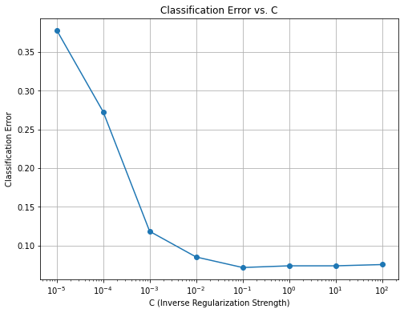

```python
# Initialize a list to store classification errors
classification_errors = []

for model in LogisticRegression_trained:
    # Predict on the testing set
    y_pred = model.predict(X_test_standardized)

    # Calculate the classification error
    # error_rate = 1 - model.score(X_test_standardized, y_test)
    # error_rate = np.mean(y_test != y_pred)
    error_rate = 1 - accuracy_score(y_test, y_pred)
    classification_errors.append(error_rate)


# Plot the classification errors
plt.figure(figsize=(8, 6))
plt.semilogx(C_values, classification_errors, marker='o')
plt.xlabel('C (Inverse Regularization Strength)')
plt.ylabel('Classification Error')
plt.title('Classification Error vs. C')
plt.grid()
plt.show()
```

#### c) Report the optimal parameter *C* and its misclassifcation error.

```python
# Find the index of the minimum value in error_rates
min_index = classification_errors.index(min(classification_errors))
best_C = C_values[min_index]

print("Optimal parameter C*:", C_values[min_index])
print("Classification error of optimal value:", min(classification_errors))
```

```
Optimal parameter C*: 0.1
Classification error of optimal value: 0.07170016295491577
```

#### d) How does the classificaiton error of regularized logistic regression compare with that of support vector machine? Is there a big difference? Why?

The classification error of regularized logistic regression (0.07170016) compared to that of a Support Vector Machine (SVM) (0.07332971) is slightly lower for logistic regression. Normally, SVM performs better when there exist some outliers or other issues with the dataset. Given the tiny difference in the performance when using a testing set of 1,841 data points, I would expect the data to be nearly noiseless.

## For quetion 3 to 5, please use pycasso package.

- Please refer to the following package for pycasso:\ https://hmjianggatech.github.io/picasso/
- We will train some models via pycasso and explore how the Lambda (the parameter of controling regularization) value changes the prediction error on the testing set.
- You can choose the type of models by specifying "family" and "penalty" in the solver. The solver has the attribute "lambdas" that can return calculated lambdas.
- You need to set lambdas = (N, r) in the solver so that N lambdas will be calculated and lambda_min_ratio = r.

### Q3) Lasso Regression

```python
# !pip install pycasso
import pycasso
pycasso.test()
```

```
Picasso has been successfully imported!
Version: 0.1.2.2
```

#### a) Standardize the training set.

```python
### Import Dataset
# Load the dataset
df2_train = pd.read_csv('./Question3_train.csv')
df2_test = pd.read_csv('./Question3_test.csv')

# Split features and labels
X_train, y_train = df2_train.iloc[:, :-1], df2_train.iloc[:, -1]
X_test, y_test = df2_test.iloc[:, :-1], df2_test.iloc[:, -1]

# Standardize features
scaler = StandardScaler()
X_train_standardized = scaler.fit_transform(X_train)
```

#### b) Fit the training set for Question 3 using a Lasso model via pycasso. Please set lambdas=(100, 0.02) in the solver.

```python
# Assuming you have the training data as X_train and labels as y_train
# Set the lambda values and minimum lambda ratio
lambdas = (100, 0.02)

# Create a Lasso model object with the specified lambdas
lasso_model = pycasso.core.Solver(X_train_standardized, y_train, lambdas=(100, 0.02),\
                                  family='gaussian', penalty='l1', useintercept=True)

# Fit the Lasso model on the training data
lasso_model.train()
```

```
Training is over.
```

#### c) Standardize the testing set using the statistics of the training set obtained in a).

```python
# Standardize features
X_test_standardized = scaler.transform(X_test)
```

#### d) Plot the prediction error (use MSE as evaluation metric) on the standardized testing set vs. the Lambda parameter. Report the optimal parameter and its prediction error.

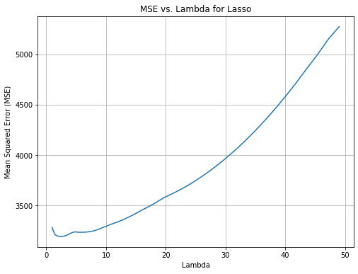

```
Optimal Lambda: 2.433371755362587
Optimal MSE: 3191.6960187522136
```

```python
# Initialize lists to store MSE values and Lambdas
mse_values = []

# Calculate MSE for each Lambda value on the standardized testing set
for lambda_value in range(lambdas[0]):
    # Make predictions on the standardized testing set
    y_pred = lasso_model.predict(X_test_standardized, lambdidx=lambda_value)

    # Calculate Mean Squared Error (MSE)
    mse = mean_squared_error(y_test, y_pred)
    mse_values.append(mse)

# Find the index of the minimum MSE
optimal_index = np.argmin(mse_values)
optimal_lambda = lasso_model.lambdas[optimal_index]
optimal_mse = mse_values[optimal_index]

# Plot MSE vs. Lambda
plt.figure(figsize=(8, 6))
plt.plot(lasso_model.lambdas, mse_values)
plt.xlabel('Lambda')
plt.ylabel('Mean Squared Error (MSE)')
plt.title('MSE vs. Lambda for Lasso')
plt.grid()
plt.show()

# Report the optimal parameter and its prediction error
print(f"Optimal Lambda: {optimal_lambda}")
print(f"Optimal MSE: {optimal_mse}")
```

#### e) How many variables does the optimal parameter select?

```python
lasso_model_coef = pd.DataFrame(lasso_model.coef()['beta'])
print("Number of variables selected: ", np.count_nonzero(lasso_model_coef.iloc[optimal_index, :]))
```

```
Number of variables selected:  18
```

#### f) Train a linear regression model (without any regularization) using only the variables selected in e). Report the prediction error on the standardized testing set.

```python
nonzero_indices = np.nonzero(np.array(lasso_model_coef.iloc[optimal_index, :]))[0]

from sklearn.linear_model import LinearRegression

# Create a new feature matrix with only the selected variables
X_train_selected = X_train_standardized[:, nonzero_indices]  # Use standardized training data
X_test_selected = X_test_standardized[:, nonzero_indices]    # Use standardized testing data

# Train a linear regression model on the selected features
linear_reg_model = LinearRegression()

# Fit the model on the selected feature matrix and training labels
linear_reg_model.fit(X_train_selected, y_train)

# Make predictions on the standardized testing set using the model
y_pred = linear_reg_model.predict(X_test_selected)

# Calculate the Mean Squared Error (MSE) on the testing set
mse = mean_squared_error(y_test, y_pred)

print(f"Mean Squared Error (MSE) on testing set: {mse}")
```

```
Mean Squared Error (MSE) on testing set: 3286.337866330763
```

#### g) How does the prediction error in f) compare with the prediction error in d)? Why?

The prediction error of the linear regression model in (f) is 3286.3379, whereas the prediction error of the lasso regression in (d) is at its minimum, 3191.6960. One of the differences between the models is that we perform an extensive search for an ideal regularization parameter in (d), while for (f), we just use the best values selected in the lasso regression model. Therefore, it could be, without any regularization, that there exists a slight overfitting in the linear regression model, or that if we were to apply a forward search algorithm to select the ideal features for the linear regression, the model might choose different columns, and its testing error could decrease (converge to lasso regression).

#### h) How does the regularization parameter affect bias and variance.

A larger regularization parameter incurs larger bias and smaller variance, while a smaller regularization parameter incurs smaller bias and larger variance. This tradeoff between bias and variance is fundamental in machine learning models. It iss precisely why we observe a U-shaped curve in (d), illustrating how the relationship between bias and variance can impact the model's performance.

#### i) Plot out the regularization path (coefficient vs regularization parameter lambda).

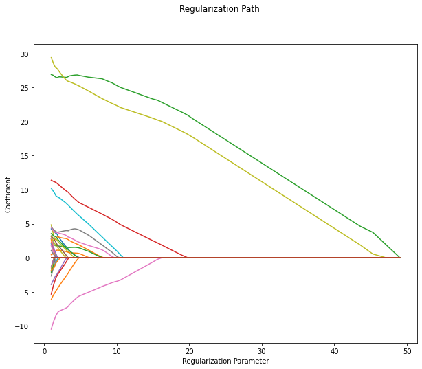

```python
plt.figure(figsize=(10, 8))
lasso_model.plot()
```

#### j) Based on the regularization path, please list the most important 5 variables.

```python
# To get the indices of the five largest values
largest_indices = np.abs(lasso_model_coef.iloc[optimal_index, :]).nlargest(5).index

# Print the column labels associated with the indices
print("Column labels of Five Largest Values:")
print(df2_test.columns[largest_indices])
```

```
Column labels of Five Largest Values:
Index(['ltg', 'bmi', 'map', 'age:sex', 'hdl'], dtype='object')
```

### Q4) Logistic Lasso Regression

#### a) Fit the spam dataset using a Logistic Lasso model via pycasso (You need to follow the same standardization procedure as in Q1). Please set lambdas=(100, 0.05) in the solver.

```python
# Split features and labels
X_train, y_train = df1_train.iloc[:, :-1], df1_train.iloc[:, -1]
X_test, y_test = df1_test.iloc[:, :-1], df1_test.iloc[:, -1]

# Standardize features
scaler = StandardScaler()
X_train_standardized = scaler.fit_transform(X_train)
X_test_standardized = scaler.transform(X_test)

# Set the lambda values and minimum lambda ratio
lambdas = (100, 0.05)

# Create a Lasso model object with the specified lambdas
log_lasso_model = pycasso.core.Solver(X_train_standardized, y_train, lambdas=lambdas,\
                                  family='binomial', penalty='l1')

# Fit the Lasso model on the training data
log_lasso_model.train()
```

```
Training is over.
```

#### b) Plot the misclassification error on the standardize testing set vs. the Lambda parameter. Report the optimal parameter and its misclassifcation error.

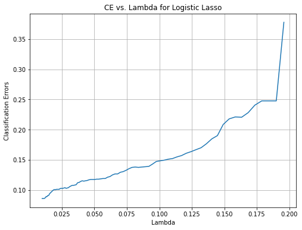

```
Optimal Lambda for Logistic Lasso: 0.011389197997957866
Optimal CE: 0.08582292232482347
```

```python
# Initialize lists to store ME values and and y_pred
classification_errors = []
y_preds = []

# Calculate MSE for each Lambda value on the standardized testing set
for lambda_value in range(lambdas[0]):
    # Make predictions on the standardized testing set
    y_pred = log_lasso_model.predict(X_test_standardized, lambdidx=lambda_value)
    y_preds.append(y_pred)

    # Calculate the Classification Error
    for j in range(len(y_pred)):
        if y_pred[j] <= 0:
            y_pred[j] = 0
        else:
            y_pred[j] = 1

    classification_errors.append(1 - accuracy_score(y_test, y_pred))
    # classification_errors.append(np.mean(y_test != y_pred))


# Find the index of the minimum MSE
optimal_index = np.argmin(classification_errors)
optimal_lambda = log_lasso_model.lambdas[optimal_index]
optimal_ce = classification_errors[optimal_index]

# Plot MSE vs. Lambda
plt.figure(figsize=(8, 6))
plt.plot(log_lasso_model.lambdas, classification_errors)
plt.xlabel('Lambda')
plt.ylabel('Classification Errors')
plt.title('CE vs. Lambda for Logistic Lasso')
plt.grid()
plt.show()

# Report the optimal parameter and its prediction error
print(f"Optimal Lambda for Logistic Lasso: {optimal_lambda}")
print(f"Optimal CE: {optimal_ce}")
```

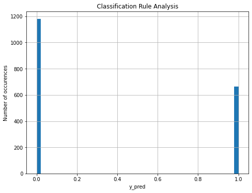

```
Mean of y_pred: 0.35958718087995656
Mean of y_test: 0.3780554046713743
```

```python
# Plot Histogram of y_pred to set a classification rule
plt.figure(figsize=(8, 6))
plt.hist(y_preds[optimal_index], bins=50);
plt.xlabel('y_pred')
plt.ylabel('Number of occurences')
plt.title('Classification Rule Analysis')
plt.grid()
plt.show()

print(f"Mean of y_pred: {np.mean(y_preds[optimal_index])}")
print(f"Mean of y_test: {np.mean(y_test)}")
```

#### c) How many variables does the optimal parameter select?

```python
log_lasso_model_coef = pd.DataFrame(log_lasso_model.coef()['beta'])
print("Number of variables selected: ", np.count_nonzero(log_lasso_model_coef.iloc[optimal_index, :]))
```

```
Number of variables selected:  34
```

#### d) Train a logistic regression model (without any regularization) using only the variables selected in e). Report the prediction error on the standardized testing set.

```python
nonzero_indices = np.nonzero(np.array(log_lasso_model_coef.iloc[optimal_index, :]))[0]

# Create a new feature matrix with only the selected variables
X_train_selected = X_train_standardized[:, nonzero_indices]  # Use standardized training data
X_test_selected = X_test_standardized[:, nonzero_indices]    # Use standardized testing data

# Train a logistic regression model on the selected features
logistic_reg_model = LogisticRegression()

# Fit the model on the selected feature matrix and training labels
logistic_reg_model.fit(X_train_selected, y_train)

# Make predictions on the standardized testing set using the model
y_pred = logistic_reg_model.predict(X_test_selected)

# Calculate the classification error on the testing set
classification_error = 1 - accuracy_score(y_test, y_pred)

print(f"Classification Error on testing set: {classification_error}")
```

```
Classification Error on testing set: 0.08093427485062465
```

#### e) How does the prediction error in d) compare with the prediction error in b)? Why?

Using the 34 selected variables from the trained model in (b), the logistic regression model leads to a prediction error of 0.080934 in (d), whereas the regularized logistic lasso regression has a classification error of 0.085823 in (b). Since the model's inherent linearity already has a low level of complexity, we cannot gain as much as one would think by applying the regularization procedure. Another source of noise to be mentioned in (b) is the classification of the predicted response variables, where I used (-infinity, 0] to classify a value as 0, otherwise 1. Looking at my classification rule analysis (plot and numbers), we can clearly see that the model slightly favors 0's since we included that value in the left interval. That being said, the standard logistic regression model slightly outperforms the regularization model.

#### f) How does the regularization parameter affect bias and variance.

While a larger regularization parameter results in larger bias and smaller variance, and a smaller regularization parameter results in smaller bias and larger variance, this relationship does not necessarily manifest as a bias-variance tradeoff in (b). Unlike previous cases (Q3), we do not observe a U-shaped curve. This is due to the model's inherent linearity, which maintains a low level of complexity even with small regularization parameters.

#### g) Plot out the regularization path (coefficient vs regularization parameter lambda).

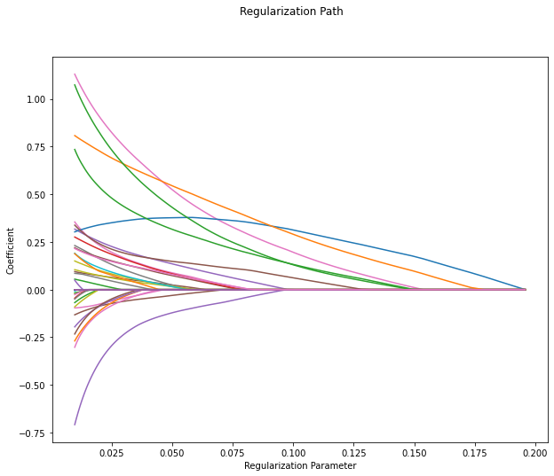

```python
plt.figure(figsize=(10, 8))
log_lasso_model.plot()
```

### Q5) Logistic MCP Regression

#### a) Fit the provided spam dataset using a Logistic model with MCP regularization via pycasso (You need to follow the same standardization procedure as in Q1). Please set lambdas=(100, 0.05) and gamma=1.25.

```python
# Split features and labels
X_train, y_train = df1_train.iloc[:, :-1], df1_train.iloc[:, -1]
X_test, y_test = df1_test.iloc[:, :-1], df1_test.iloc[:, -1]

# Standardize features
scaler = StandardScaler()
X_train_standardized = scaler.fit_transform(X_train)
X_test_standardized = scaler.transform(X_test)

# Set the lambda values, minimum lambda ratio and gamma
lambdas = (100, 0.05)
gamma = 1.25

# Create a Lasso model object with the specified lambdas
log_mcp_model = pycasso.core.Solver(X_train_standardized, y_train, lambdas,\
                                  family='binomial', penalty='mcp', gamma=gamma)

# Fit the Lasso model on the training data
log_mcp_model.train()
```

```
Training is over.
```

#### b) Plot the misclassification error on the testing set vs. the Lambda parameter. Report the optimal parameter and its misclassifcation error.

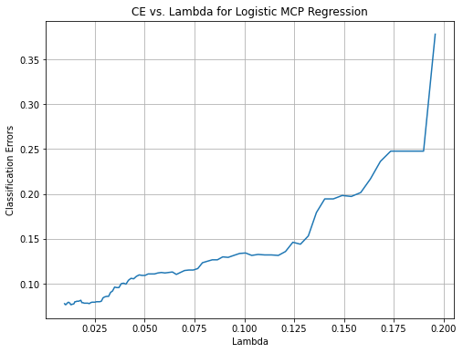

```
Optimal Lambda for Logistic MCP Regression: 0.013249568315423899
Optimal CE: 0.07658881042911458
```

```python
# Initialize lists to store ME values and and y_pred
mcp_classification_errors = []
y_preds = []

# Calculate MSE for each Lambda value on the standardized testing set
for lambda_value in range(lambdas[0]):
    # Make predictions on the standardized testing set
    y_pred = log_mcp_model.predict(X_test_standardized, lambdidx=lambda_value)
    y_preds.append(y_pred)

    # Calculate the Classification Error

    for j in range(len(y_pred)):
        if y_pred[j] <= 0:
            y_pred[j] = 0
        else:
            y_pred[j] = 1

    mcp_classification_errors.append(1 - accuracy_score(y_test, y_pred))
    # mcp_classification_errors.append(np.mean(y_test != y_pred))


# Find the index of the minimum MSE
optimal_index = np.argmin(mcp_classification_errors)
optimal_lambda = log_mcp_model.lambdas[optimal_index]
optimal_ce = mcp_classification_errors[optimal_index]

# Plot MSE vs. Lambda
plt.figure(figsize=(8, 6))
plt.plot(log_mcp_model.lambdas, mcp_classification_errors)
plt.xlabel('Lambda')
plt.ylabel('Classification Errors')
plt.title('CE vs. Lambda for Logistic MCP Regression')
plt.grid()
plt.show()

# Report the optimal parameter and its prediction error
print(f"Optimal Lambda for Logistic MCP Regression: {optimal_lambda}")
print(f"Optimal CE: {optimal_ce}")
```

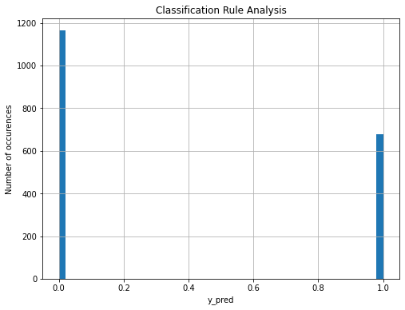

```
Mean of y_pred: 0.3677349266702879
Mean of y_test: 0.3780554046713743
```

```python
# Plot Histogram of y_pred to set a classification rule
plt.figure(figsize=(8, 6))
plt.hist(y_preds[optimal_index], bins=50);
plt.xlabel('y_pred')
plt.ylabel('Number of occurences')
plt.title('Classification Rule Analysis')
plt.grid()
plt.show()

print(f"Mean of y_pred: {np.mean(y_preds[optimal_index])}")
print(f"Mean of y_test: {np.mean(y_test)}")
```

#### c) How many variables does the optimal parameter select?

```python
log_mcp_model_coef = pd.DataFrame(log_mcp_model.coef()['beta'])
print("Number of variables selected: ", np.count_nonzero(log_mcp_model_coef.iloc[optimal_index, :]))
```

```
Number of variables selected:  31
```

#### d) Plot out the regularization path (coefficient vs regularization parameter lambda)

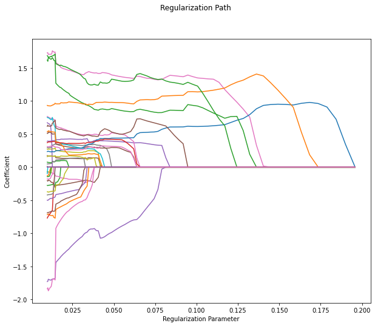

```python
plt.figure(figsize=(10, 8))
log_mcp_model.plot()
```

#### e) Plot the misclassification error vs. the number of nonzero entries in the logistic regression coefficient using MCP vs Lasso in Q4 and Q5 by varying the regularizaiton parameter. What do you observe? Why?

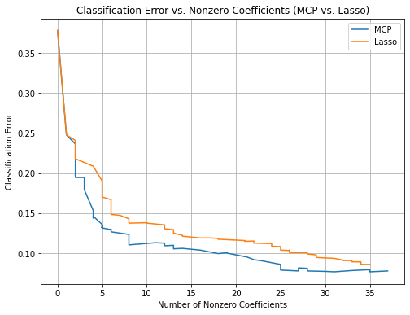

```python
# Sum nonzero entries by rows
lasso_nonzero_counts = np.sum(log_lasso_model_coef.iloc[:, :] != 0, axis=1)
mcp_nonzero_counts = np.sum(log_mcp_model_coef.iloc[:, :] != 0, axis=1)

# lambdas – The parameters of controling regularization.

# Plot classification error vs. the number of nonzero entries for MCP and Lasso
plt.figure(figsize=(8, 6))
plt.plot(mcp_nonzero_counts, mcp_classification_errors, label='MCP',) # marker='o'
plt.plot(lasso_nonzero_counts, classification_errors, label='Lasso',)
plt.xlabel('Number of Nonzero Coefficients')
plt.ylabel('Classification Error')
plt.title('Classification Error vs. Nonzero Coefficients (MCP vs. Lasso)')
plt.legend()
plt.grid()
plt.show()
```

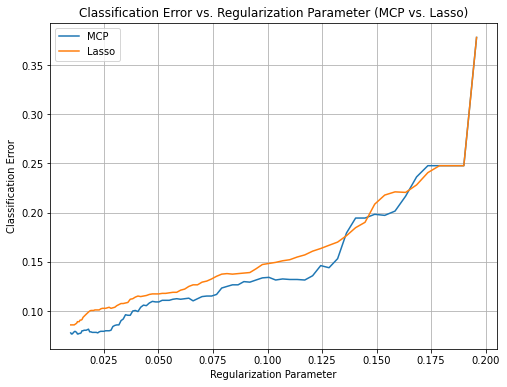

```python
# Plot classification error vs. the regularization parameter for MCP and Lasso
plt.figure(figsize=(8, 6))
plt.plot(log_mcp_model.lambdas, mcp_classification_errors, label='MCP')
plt.plot(log_lasso_model.lambdas, classification_errors, label='Lasso')
plt.xlabel('Regularization Parameter')
plt.ylabel('Classification Error')
plt.title('Classification Error vs. Regularization Parameter (MCP vs. Lasso)')
plt.legend()
plt.grid()
plt.show()
```

### Q6) K-Fold Cross Validation

- Similar to Q1, we will use the spam dataset to train linear SVM Classifiers using K-Fold cross validation to optimize C. Ignore the warnings of SVM.
- Data need to be standardized as the way you did in Q1.
- Please refer to the following package for K-Fold cross validation:\ https://scikit-learn.org/stable/modules/generated/sklearn.model_selection.KFold.html
- For your linear SVM model, set max_iter = $10^4$ and tol = 1e-2. Ignore the warnings of SVM.

#### a) Please find an optimal C for a range of *C* values $\{10^{-5}, 10^{-4}, 10^{-3}, \ldots, 10^{1}, 10^{2}\}$ under different values of K = [2, 3, 5, 7, 10].

```python
# Split features and labels
X_train, y_train = df1_train.iloc[:, :-1], df1_train.iloc[:, -1]
X_test, y_test = df1_test.iloc[:, :-1], df1_test.iloc[:, -1]

# Standardize features
scaler = StandardScaler()
X_train_standardized = scaler.fit_transform(X_train)
X_test_standardized = scaler.transform(X_test)

from sklearn.model_selection import KFold
# Create a list of C values to test
C_values = [10**i for i in range(-5, 3)]  # [1e-5, 1e-4, 1e-3, 1e-2, 1e-1, 1, 10, 100]

# Create a list of K values for cross-validation
K_values = [2, 3, 5, 7, 10]

# Initialize variables to keep track of the best C and its corresponding score
best_C = None
best_score = np.inf

# Create lists to store results for different K values
k_values = []
accuracy_scores = []
plot_dct = {}

# Perform K-Fold cross-validation for each combination of C and K
for C in tqdm(C_values):
    plot_dct[str(C)] = {}
    for K in K_values:
        kf = KFold(n_splits=K, shuffle=True, random_state=7)  # K-Fold cross-validation
        scores = []

        for train_index, test_index in kf.split(X_train_standardized):
            X_train_subset, X_test_subset = X_train_standardized[train_index], X_train_standardized[test_index]
            y_train_subset, y_test_subset = y_train[train_index], y_train[test_index]

            model = LinearSVC(C=C, max_iter=int(1e4), tol=1e-2, random_state=7)
            model.fit(X_train_subset, y_train_subset)
            y_pred_subset = model.predict(X_test_subset)

            # Calculate the accuracy score
            score = 1 - accuracy_score(y_test_subset, y_pred_subset)
            scores.append(score)

        # Calculate the average score
        avg_score = np.mean(scores)
        plot_dct[str(C)][str(K)] = avg_score

        # Check if this combination is the best so far
        if avg_score < best_score:
            best_score = avg_score
            best_C = C


# Print the optimal C and its corresponding score
print(f"Optimal C: {best_C}")
print(f"Corresponding Score (accuracy_score): {best_score}")
```

```
Optimal C: 100
Corresponding Score (accuracy_score): 0.06920289855072466
```

#### b) Retrain the model on the entire training set with the optimal C and report classification error on the testing set.

```python
# # Split features and labels
# X_train, y_train = df1_train.iloc[:, :-1], df1_train.iloc[:, -1]
# X_test, y_test = df1_test.iloc[:, :-1], df1_test.iloc[:, -1]

# # Standardize features
# scaler = StandardScaler()
# X_train_standardized = scaler.fit_transform(X_train)
# X_test_standardized = scaler.transform(X_test)

# Set the optimal C value obtained in the previous step
optimal_C = best_C  # Replace with your optimal C

# Train the linear SVM model on the entire training set with the optimal C
model = LinearSVC(C=optimal_C, max_iter=int(1e4), tol=1e-2, random_state=1)
model.fit(X_train_standardized, y_train)

# Make predictions on the standardized testing set
y_pred = model.predict(X_test_standardized)

# Calculate the classification error on the testing set
classification_error_val = 1 - accuracy_score(y_test, y_pred)

print(f"Classification Error on the testing set: {classification_error_val}")
```

```
Classification Error on the testing set: 0.08093427485062465
```

#### c) Explain how the classification error on the validation datasets and the testing datasets change with K. Why?

In k-fold cross-validation, the data is divided into k parts, using k-1 parts to train the model and calculating the classification error on the kth part of the dataset (in this case, the training dataset). Since the training set has 2,760 rows, in our extreme case when k=10, the validation set is reduced to 276 data points. Additionally, one can increase the randomness by shuffling the data before applying k-fold cross-validation.

According to my algorithm in (a), C* is 100 with an accuracy score of 0.069203 using k=3. When we look at the two plots below, the first one shows that the validation error first decreases and then, after some point, starts to increase. In parallel, on the second plot, the test error remains the same for all values of k except for k=2, where a different value of C generates the optimal case. Another interesting fact to mention is that the cross-validation errors are smaller than the test error. This is because cross-validation still tends to overfit the data.

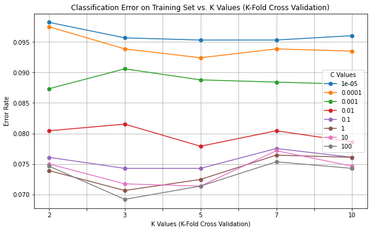

```python
df_plot = pd.DataFrame(plot_dct)

# Plot the DataFrame
plt.figure(figsize=(8, 6))
df_plot.plot(marker='o', figsize=(10, 6));

# Add labels and legend
plt.xlabel('K Values (K-Fold Cross Validation)')
plt.ylabel('Error Rate')
plt.title('Classification Error on Training Set vs. K Values (K-Fold Cross Validation)')
plt.legend(title='C Values')
plt.grid()

# Show the plot
plt.show()
```

```python
# Manually combined from the graph above of 'C value': k pairs
min_columns = {'1': [2], '100': [3, 5, 7, 10]}

# Initialize a dictionary to store classification errors for each 'C value'
classification_errors = {}

# Iterate through the 'C value': 'k' pairs and set C accordingly
for c_value, k_values in tqdm(min_columns.items()):
    C = float(c_value)
    errors_for_c = []

    # Iterate through each 'k' value for the current 'C' value
    for k in k_values:
        # Train the linear SVM model with the specified C
        model = LinearSVC(C=C, max_iter=int(1e4), tol=1e-2, random_state=1)
        model.fit(X_train_standardized, y_train)

        # Make predictions on the standardized testing set
        y_pred = model.predict(X_test_standardized)

        # Calculate the classification error on the testing set
        classification_error_val = 1 - accuracy_score(y_test, y_pred)

        # Append the classification error to the list for this 'k' value
        errors_for_c.append((k, classification_error_val))

    # Store the list of errors in the dictionary with the 'C' value as the key
    classification_errors[f'C={C}'] = errors_for_c
```

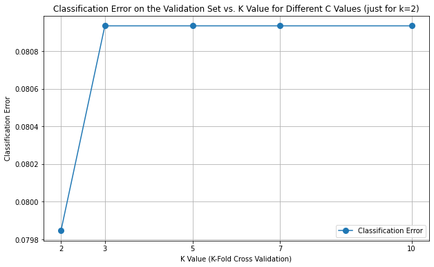

```python
# Extract C values, k values, and errors
C_values = []
k_values = []
errors = []

for c_key, k_errors in classification_errors.items():
    for k, error in k_errors:
        C_values.append(c_key)
        k_values.append(k)
        errors.append(error)

# Create the line plot
plt.figure(figsize=(10, 6))
plt.plot(k_values, errors, marker='o', linestyle='-', markersize=8, label='Classification Error')

# Set labels and title
plt.xlabel('K Value (K-Fold Cross Validation)')
plt.ylabel('Classification Error')
plt.title('Classification Error on the Validation Set vs. K Value for Different C Values (just for k=2)')

# Customize the x-axis ticks
plt.xticks(k_values)

# Add a legend
plt.legend()

# Show the plot
plt.grid(True)
plt.show()
```